# Practical Guide

## Practical Introduction to Simple Linear Regression

In this session, I will provide a practical guide and introduction to the linear regression techniques. I design this tutorial to be as accessible as possible to anyone (including those with little familiarity with Linear Algebra). However, understanding some summation rules and the chain rule are important to understand this the content below. I provide examples of these below:

#### Summation Notation

1. $ \displaystyle\sum_{i=1}^{N} x_i = x_0 + x_1 + x_2 + ... + x_n$
2. $ \displaystyle\sum_{i=1}^{N} cx_i = c\displaystyle\sum_{i=1}^{N}x_i$ where c is constant
3. $ \bar{x} = \frac{1}{N}\displaystyle\sum_{i=1}^{N}x_i$

#### Chain Rule

Formally:

Suppose: $$h(x) = f(g(x))$$ Then the derivative of function $h(x)$ $$h^{\prime}(x) = f^{\prime}(g(x))*g^{\prime}(x)$$

#### Example:

The derivative of $f(x) = (3x^2 + 1)^2$ is: $$f^{\prime}(x) = 2(3x^2 + 1)6x$$

Okay, we are good to go!

### Simple Linear Regression

#### 1. Loading Necessary Packages

Loading data manipulation and visualization packages

```python
import numpy as np
import pandas as pd
import matplotlib.pyplot as plt

%matplotlib inline
%config InlineBackend.figure_format = 'retina'
```

#### 2. Loading and plotting data

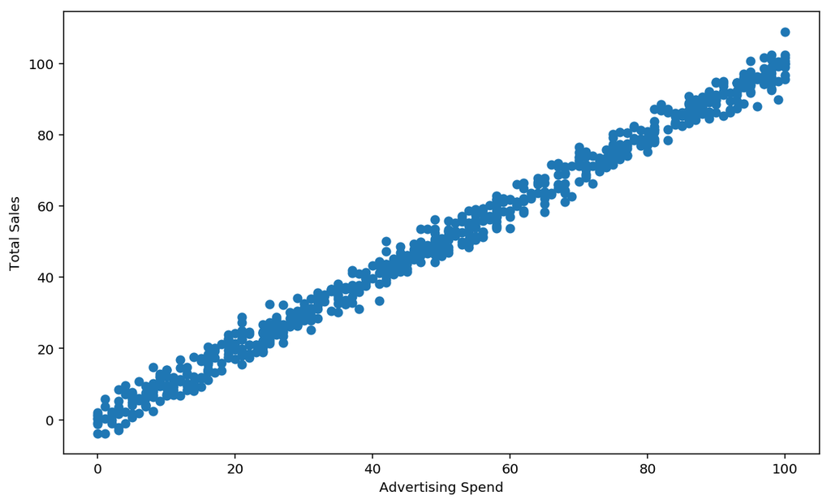

```python
data = pd.read_csv('../Data/linear.csv')
data.dropna(inplace=True)

# Plotting Data
fig = plt.figure(figsize=(10, 6))
plt.scatter(data['x'], data['y'], marker='o')
plt.xlabel('Advertising Spend')
plt.ylabel('Total Sales')
```

Of course, in the real world, we don't get clean linear data but we will use this for demonstrating linear regression. Based on the data above, we see there is a linear trend which can be estimated by a linear equation. Let's define the linear equation

### Linear Regression Form:

$$ y=\beta_0 + \beta_1*x + \epsilon$$

Based on the equation below, we want to estimate the parameters $\beta_0$ and $\beta_1$, such that with an input $x$, we can predict the resulting $y$ value. You can think of randomly assigning values to $\beta_0$ and $\beta_1$ but we will not be able to determine which values provide the closest correct value of $y$. This is where the measure of fit comes into play.

### Measure of Fit

Measure of fit defined how good our parameters are at making predictions. We can simply look at the overall difference between predicted values of all observations against the actual values to determine the overall measure of fit. We can do this by computing the residual:

$$residual = y - \widehat{y}$$

where:  
$y: actual\ value\ of\ observations$  
$\widehat{y}: predicted\ value\ of\ observations$

To obtain the overall difference, we can take the sum of residuals, however, we lose information about the measure of fit given that some values will be over-predicted and some under-predicted. To reconcile this, we compute the sum of squared residuals.

Mathematically:

$$ RSS = \sum_{n=i}^{N} ({y_i - \widehat{y_i}})^2$$

Note that the above formula can be written as: $$ \sum_{n=i}^{N} (y_i - (\widehat{\beta_0} + \widehat{\beta_1}*x))^2 = \sum_{n=i}^{N} (\epsilon_i)^2$$

#### Estimating the Parameters

Now that we have a measure of fit, we need to find the values of $\beta_0$ and $\beta_1$ that minimized the measure of fit. That is find the values of $\beta_0$ and $\beta_1$ that provide the lowest sum of squared error (RSS). Our cost function is RSS and we then write our objective function as (minizing the cost function):

$$\min_{\beta_0, \beta_1} \sum_{n=i}^{N} (y_i - (\widehat{\beta_0} + \widehat{\beta_1}*x))^2$$

Luckily, the cost function is a convex function, therefore we can use gradients to solve for $\beta_0$ and $\beta_1$ that minimize the cost function. Below are two solutions:

### Closed-Form Solution

#### Case 1: $\beta_0$

$$ \frac{\partial RSS(\beta_0, \beta_1)} {\partial \beta_0} = \sum 2[y_i - (\widehat{\beta_0} + \widehat{\beta_1} x_i)](-1) $$

Equate the partial to Zero:

$$ 0 = -2 \sum y_i -\sum \widehat{\beta_0} - \sum \widehat{\beta_1} x_1 $$

$$\sum \widehat{\beta_0} = \sum y_i - \widehat{\beta_1} \sum x_i$$

Recall, sum of a constant is equal to constant multiplied by n:

$$n\widehat{\beta_0} = \sum y_i - \widehat{\beta_1} \sum x_i$$

$$\widehat{\beta_0} = \frac {\sum y_i}{n} - \frac{ \widehat{\beta_1} \sum x_i} {n}$$

Therefore: $$\widehat{\beta_0} = \bar y - \widehat{\beta_1}*\bar x $$

#### Case 2: $\beta_1$

$$ \frac{\partial RSS(\beta_0, \beta_1)} {\partial \beta_0} = \sum 2[y_i - (\widehat{\beta_0} + \widehat{\beta_1} x_i)](-x_i)$$

Equate the partial to Zero: $$ 0 = -2 \sum y_i x_i - \sum \widehat{\beta_0} x_i - \sum \widehat{\beta_1} x_1^2 $$
$$ 0 = -2 \sum y_i x_i - \widehat{\beta_0} \sum x_i - \widehat{\beta_1} \sum x_1^2 $$

Substitute $\beta_0$ in the equation: $$ 0 = -2 \sum y_i x_i - (\bar y + \widehat{\beta_1} \bar x) \sum x_i - \widehat{\beta_1} \sum x_1^2 $$
$$ 0 = \sum y_i x_i - \bar y \sum x_i + \widehat{\beta_1} \bar x \sum x_i - \widehat{\beta_1} \sum x_1^2 $$

We can simplify the equation using summation rules to:

$$ \widehat {\beta_1} = \frac {\sum x_i y_i - n\bar x^2} {\sum x_i^2 - n\bar x^2} $$

$$ \widehat {\beta_1} = \frac {\sum (x - \bar x) (y - \bar y)} {\sum (x - \bar x)^2} = \frac {Cov(X,Y)}{Var(x)}$$

### Let's compute the Solution in Python

```python
def closed_form_solution(feature, target):
    """
    Computing the Close Form Solution
    """
    numerator = np.sum( (feature - np.mean(feature)) * (target - np.mean(target)) )
    denominator = np.sum((feature - np.mean(feature))**2)
    beta = numerator/denominator
    alpha = np.mean(target) - beta*(np.mean(feature))
    return alpha, beta
```

Now, let's compute the values of alpha and beta.

```python
alpha, beta = closed_form_solution(data.x, data.y)
print(alpha, beta)
```

```
-0.10726546430105088 1.0006563818563046
```

### Prediction

Now let's build the code to perform predictions so that we can visualize our predicted values.

```python
def prediction(alpha, beta, features):
    """ Computers the Predictions """
    return alpha + beta*features
```

```python
data['pred'] = prediction(alpha, beta, data.x)
```

### Visualize our Prediction

Now, let's plot the predicted values against our scatter plot and see how well we fit the data.

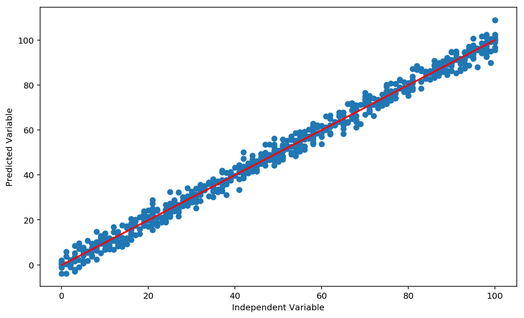

```python
fig = plt.figure(figsize=(10, 6))
plt.scatter(data['x'], data['y'], marker='o')
plt.plot(data['x'], data['pred'], color='red')
plt.xlabel('Independent Variable')
plt.ylabel('Predicted Variable')
```

### Implementing this with Sklearn

Often times in the real world, we will not need to compute our parameters but rather leverage existing packages to compute these parameters. Below is the same implementation using sklearn package

```python
from sklearn import datasets, linear_model
```

#### Creating the model object and fitting the model

Now we initialize linear model and fit it to our dataset. Notice that the input has to be a matrix for this to work.

```python
model = linear_model.LinearRegression(fit_intercept=True)
model.fit(data[['x']], data['y'])
```

```
LinearRegression(copy_X=True, fit_intercept=True, n_jobs=1, normalize=False)
```

#### Model Coefficients

Now we can look at returning the model coefficients from sklearn. Notice the result is equivalent to our closed form solution.

```python
print(model.coef_)
print(model.intercept_)
```

```
[1.00065638]
-0.10726546430097272
```

This concludes the initial introduction of Simple Linear Regression, in the next notebook, we will use gradient descent to estimate the parameters.